# Violence Score

```r
library(tidyverse)
library(magrittr)
source('functions.r')

load("Table_construction.Rdata") #loading beau's version of data
```

```r
features = features %>%
  # Add other useful information:
  inner_join(
    data_before %>%
      select(person_id, screening_date, people) %>%
      unnest() %>%
      select(person_id, screening_date, race, sex, name),
    by = c("person_id","screening_date")
  ) %>%
  inner_join(features_on, by = c("person_id","screening_date")) %>%
  inner_join(outcomes, by = c("person_id","screening_date")) %>%

  # Create as many features as possible:
  mutate(
    raw_score = `Risk of Violence_raw_score`, # Adjust for violent/general
    decile_score = `Risk of Violence_decile_score`, # Adjust for violent/general
    p_juv_fel_count = pmin(p_juv_fel_count,2),
    p_felprop_violarrest = pmin(p_felprop_violarrest,5),
    p_murder_arrest = pmin(p_murder_arrest,3),
    p_felassault_arrest = pmin(p_felassault_arrest,3),
    p_misdemassault_arrest = pmin(p_misdemassault_arrest,3),
    #p_famviol_arrest = pmin(p_famviol_arrest,3),
    p_sex_arrest = pmin(p_sex_arrest,3),
    p_weapons_arrest = pmin(p_weapons_arrest,3),
    p_n_on_probation = pmin(p_n_on_probation,5),
    p_current_on_probation = pmin(p_current_on_probation,5),
    p_prob_revoke = pmin(p_prob_revoke,5),
    race_black = if_else(race=="African-American",1,0),
    race_white = if_else(race=="Caucasian",1,0),
    race_hispanic = if_else(race=="Hispanic",1,0),
    race_asian = if_else(race=="Asian",1,0),
    race_native = if_else(race=="Native American",1,0), # race == "Other" is the baseline

    # Subscales:
    vio_hist = p_juv_fel_count+
      p_felprop_violarrest+
      p_murder_arrest+
      p_felassault_arrest+
      p_misdemassault_arrest+
      #p_famviol_arrest+
      p_sex_arrest+
      p_weapons_arrest,
    history_noncomp=p_prob_revoke+
      p_probation+p_current_on_probation+
      p_n_on_probation,

    # Filters (TRUE for obserations to keep)
    filt1 = `Risk of Recidivism_decile_score` != -1, `Risk of Violence_decile_score` != -1, # Filter 1
    filt3 = !is.na(current_offense_date), # Filter 3
    filt4 = current_offense_date <= current_offense_date_limit, # Filter 4
    filt5 = p_current_age > 18 & p_current_age <= 70 # Filter 5
  )
```

Risk of Violence Modelled age with a 4th degree polynomial. See broward_sheriff_data for our efforts to model it with a variety of exponentials (couldn’t get it quite right so used a polynomial in the end). ## Fit age polynomial

```r
features_f_age = features %>%
  filter(filt1,filt5) %>%
  select(p_current_age, raw_score)
lb_age = features_f_age %>%
  group_by(p_current_age) %>%
  #arrange(raw_score, .by_group=TRUE) %>%
  arrange(raw_score) %>%
  top_n(n=-1, wt=raw_score) # Fit lower bound on smallest value
mdl_age = lm(raw_score ~
               I(p_current_age^4) +
               I(p_current_age^3) +
               I(p_current_age^2) +
               p_current_age,
             data=lb_age)
# More precision for paper
summary(mdl_age)
```

```
Call:
lm(formula = raw_score ~ I(p_current_age^4) + I(p_current_age^3) +
    I(p_current_age^2) + p_current_age, data = lb_age)

Residuals:
     Min       1Q   Median       3Q      Max
-0.57815 -0.00957  0.00722  0.03974  0.13353

Coefficients:
                     Estimate Std. Error t value Pr(>|t|)
(Intercept)         1.554e+00  8.206e-01   1.894 0.061779 .
I(p_current_age^4)  4.078e-07  2.904e-07   1.404 0.164074
I(p_current_age^3) -8.818e-05  5.109e-05  -1.726 0.088148 .
I(p_current_age^2)  7.437e-03  3.227e-03   2.304 0.023731 *
p_current_age      -3.161e-01  8.631e-02  -3.662 0.000441 ***
---
Signif. codes:  0 *** 0.001 ** 0.01 * 0.05 . 0.1   1

Residual standard error: 0.09085 on 82 degrees of freedom
Multiple R-squared:  0.9799,    Adjusted R-squared:  0.979
F-statistic:  1001 on 4 and 82 DF,  p-value: < 2.2e-16
```

```r
print("Coefficients:")
```

```
[1] "Coefficients:"
```

```r
sprintf("%.20e",mdl_age$coefficients) # More precision for paper
```

```
[1] "1.55398886995612506290e+00"  "4.07808994844784392878e-07"  "-8.81767707692677913008e-05"
[4] "7.43693932415081908338e-03"  "-3.16106532728162026302e-01"
```

```r
## Add f(age) to features
features = features %>%
  mutate(
    f_age = predict(mdl_age, newdata=data.frame(p_current_age=p_current_age)),
    raw_score__f_age = raw_score - f_age,
    filt6 = raw_score >= f_age
  )
```

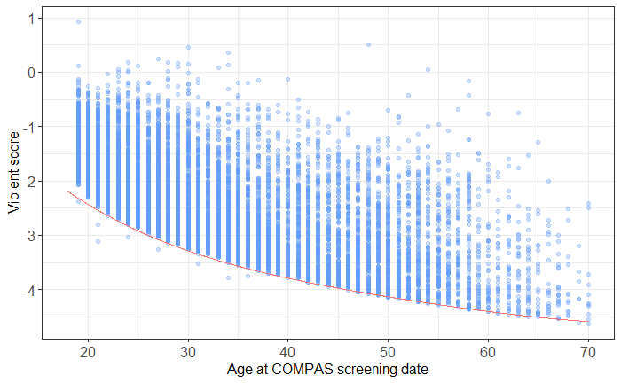

```r
## Age polynomial plot
xmin = 18
xmax = 70
xx = seq(xmin,xmax, length.out=1000)
ggplot()+
  geom_point(aes(x=p_current_age, raw_score), color="#619CFF",alpha=.3, data=features_f_age) +
  geom_line(aes(x=xx, predict(mdl_age, newdata=data.frame(p_current_age=xx))),color="#F8766D") +
  theme_bw()+
  xlim(xmin,xmax)+
  xlab("Age at COMPAS screening date") +
  ylab("Violent score") +
  theme(text = element_text(size=12),
        axis.text=element_text(size=12),
        legend.position="none")
```

Individuals on bottom edge

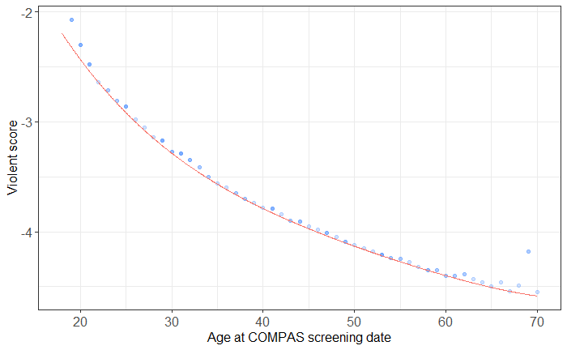

```r
#individuals on the lower bound of the age polynomial
lb_inds = features %>%
  filter(filt1,filt5, filt6) %>% #individuals who have valid scores, 18 to 70, not below lower bound
  group_by(p_current_age) %>%
  arrange(raw_score) %>%
  top_n(n=-1, wt=raw_score) # Fit lower bound on smallest value
xmin = 18
xmax = 70
xx = seq(xmin,xmax, length.out=1000)
ggplot()+
  geom_point(aes(x=p_current_age, raw_score), color="#619CFF",alpha=.3, data=lb_inds) +
  geom_line(aes(x=xx, predict(mdl_age, newdata=data.frame(p_current_age=xx))),color="#F8766D") +
  theme_bw()+
  xlim(xmin,xmax)+
  xlab("Age at COMPAS screening date") +
  ylab("Violent score") +
  theme(text = element_text(size=12),
        axis.text=element_text(size=12),
        legend.position="none")
```

```r
nrow(lb_inds)
```

```
[1] 104
```

Examining people in age_subset (bottom edge of age_poly_viol vs COMPAS score pt cloud) more closely

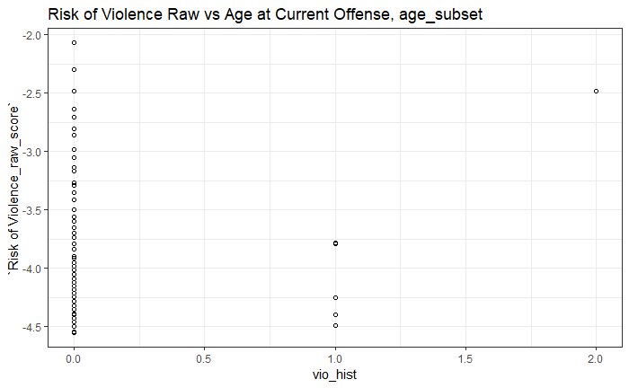

```r
ggplot(lb_inds, aes(x=vio_hist, y=`Risk of Violence_raw_score`)) +
     geom_point(shape=1)  +
     theme_bw()+
     ggtitle("Risk of Violence Raw vs Age at Current Offense, age_subset")
```

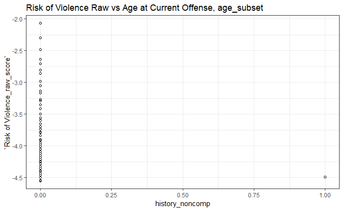

```r
ggplot(lb_inds, aes(x=history_noncomp, y=`Risk of Violence_raw_score`)) +
     geom_point(shape=1)  +
     theme_bw()+
     ggtitle("Risk of Violence Raw vs Age at Current Offense, age_subset")
```

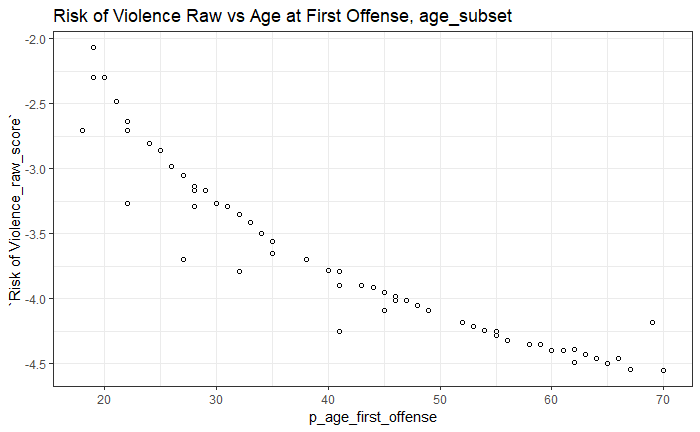

```r
ggplot(lb_inds, aes(x=p_age_first_offense, y=`Risk of Violence_raw_score`)) +
     geom_point(shape=1)  +
     theme_bw()+
     ggtitle("Risk of Violence Raw vs Age at First Offense, age_subset")
```

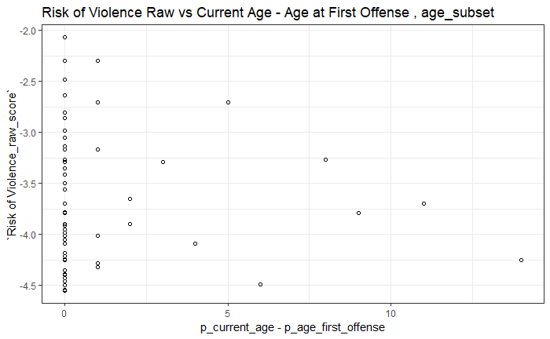

```r
ggplot(lb_inds, aes(x=p_current_age - p_age_first_offense, y=`Risk of Violence_raw_score`)) +
     geom_point(shape=1)  +
     theme_bw()+
     ggtitle("Risk of Violence Raw vs Current Age - Age at First Offense , age_subset")
```

Histograms displaying count of people in the age_subset with violence_history scores of “x”

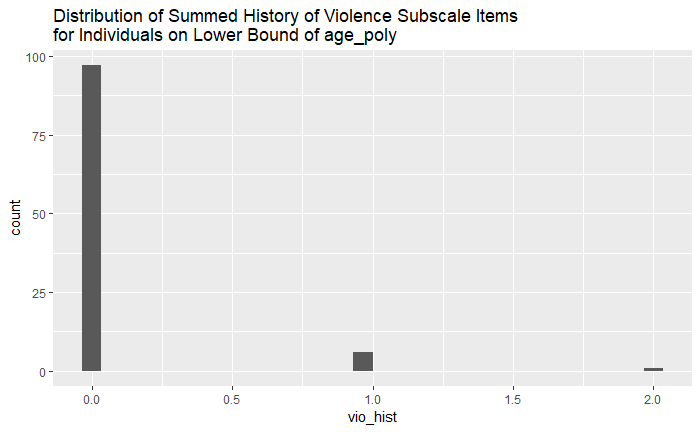

```r
#history of violence histogram
ggplot(lb_inds, aes(x=vio_hist)) +
     geom_histogram()  +
     ggtitle("Distribution of Summed History of Violence Subscale Items\nfor Individuals on Lower Bound of age_poly")
```

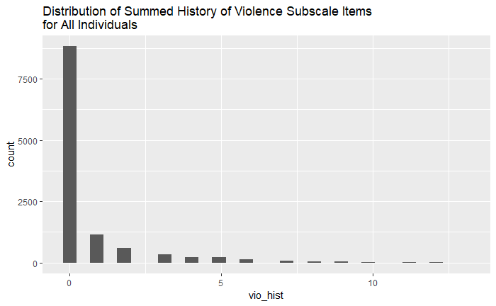

```r
#comparison histogram for all individuals who are 18-70, have scores not -1
ggplot(features%>%filter(filt1,filt5,filt6),
       aes(x=vio_hist)) +
     geom_histogram()  +
     ggtitle("Distribution of Summed History of Violence Subscale Items\nfor All Individuals")
```

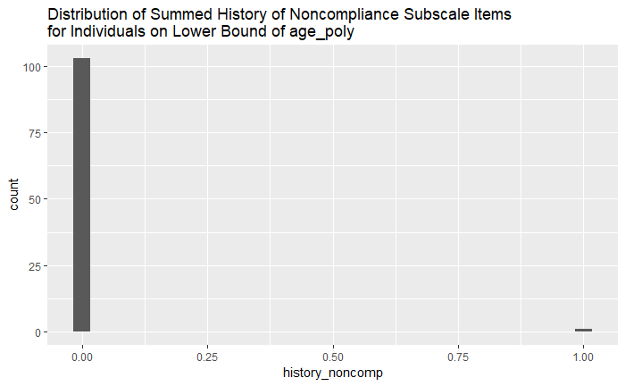

```r
#history of noncompliance histogram
ggplot(lb_inds, aes(x=history_noncomp)) +
     geom_histogram()  +
     ggtitle("Distribution of Summed History of Noncompliance Subscale Items\nfor Individuals on Lower Bound of age_poly")
```

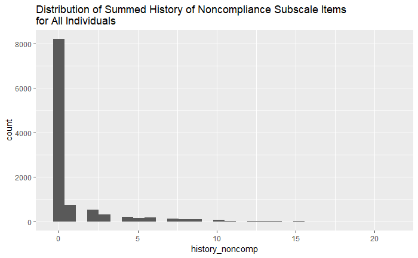

```r
#comparison histogram for all individuals
ggplot(features%>%filter(filt1,filt5,filt6),
       aes(x=history_noncomp)) +
     geom_histogram()  +
     ggtitle("Distribution of Summed History of Noncompliance Subscale Items\nfor All Individuals")
```

Question: of the crimes that people with a violence history of 1 or 2 committed, which ones were they? (Did not ask same question for history of noncompliance because there was only 1 individual nonzero history of noncomp)

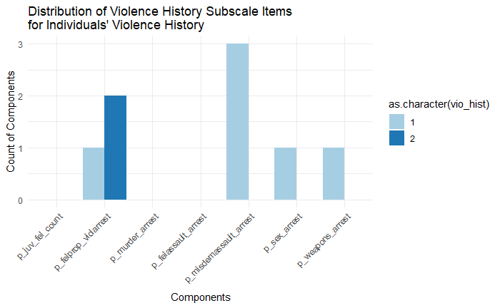

```r
#subset of 38 people
age_subset_long=lb_inds%>%
               select(vio_hist,person_id,p_juv_fel_count,p_felprop_violarrest,
                      p_murder_arrest,p_felassault_arrest,
                      p_misdemassault_arrest,#p_famviol_arrest
                      p_sex_arrest,p_weapons_arrest)%>%
               filter(vio_hist==2 | vio_hist==1)%>%
               gather(violence_history_component,component_count,p_juv_fel_count:p_weapons_arrest,factor_key = T)%>%
               group_by(vio_hist, violence_history_component)%>%
                  summarise(comp_sum = sum(component_count))
ggplot(age_subset_long, aes(x=violence_history_component,
                            y=comp_sum,fill = as.character(vio_hist))) +
      geom_bar(stat="identity", position=position_dodge())+
      # geom_bar(stat="identity", fill = "steelblue")+
      ggtitle("Distribution of Violence History Subscale Items\nfor Individuals' Violence History") +
      xlab("Components") +
      ylab("Count of Components") +
      scale_fill_discrete(name = "Violence history scores")+
      scale_fill_brewer(palette="Paired")+
      theme_minimal() +
      theme(axis.text.x = element_text(angle = 45, vjust=1,hjust=1))
```

```r
lb_inds1 = lb_inds%>%
       select(vio_hist,person_id,p_juv_fel_count,p_felprop_violarrest,
              p_murder_arrest,p_felassault_arrest,
              p_misdemassault_arrest,#p_famviol_arrest
              p_sex_arrest,p_weapons_arrest, current_offense_date, first_offense_date, screening_date)%>%
       filter(vio_hist==1)
lb_inds1
```

| p_current_age | vio_hist | person_id | p_juv_fel_count | p_felprop_violarrest | p_murder_arrest | p_felassault_arrest | p_misdemassault_arrest | p_sex_arrest | p_weapons_arrest | current_offense_date | first_offense_date | screening_date |
| --- | --- | --- | --- | --- | --- | --- | --- | --- | --- | --- | --- | --- |
| 68 | 1 | 3497 | 0 | 0 | 0 | 0 | 0 | 0 | 1 | 2014-04-27 | 2008-01-08 | 2014-04-28 |
| 60 | 1 | 9250 | 0 | 0 | 0 | 0 | 1 | 0 | 0 | 2014-05-05 | 2014-04-13 | 2014-05-06 |
| 55 | 1 | 731 | 0 | 1 | 0 | 0 | 0 | 0 | 0 | 2013-01-27 | 2013-01-26 | 2013-02-07 |
| 55 | 1 | 6323 | 0 | 0 | 0 | 0 | 1 | 0 | 0 | 2013-04-26 | 1999-06-23 | 2013-04-27 |
| 41 | 1 | 7586 | 0 | 0 | 0 | 0 | 0 | 1 | 0 | 2013-05-12 | 2013-05-11 | 2013-05-13 |
| 40 | 1 | 9028 | 0 | 0 | 0 | 0 | 1 | 0 | 0 | 2013-08-18 | 2013-06-30 | 2013-08-19 |

```r
lb_inds3 = lb_inds%>%
       select(history_noncomp,person_id, current_offense_date, first_offense_date, screening_date)%>%
       filter(history_noncomp==1)
lb_inds3
```

| p_current_age | history_noncomp | person_id | current_offense_date | first_offense_date | screening_date |
| --- | --- | --- | --- | --- | --- |
| 68 | 1 | 3497 | 2014-04-27 | 2008-01-08 | 2014-04-28 |

Possible reason for people on lower bound having criminal history? They are very old or their sole prior occurred only a few days before the screening date.

```r
lb_inds1 = lb_inds%>%
       select(non,person_id,p_juv_fel_count,p_felprop_violarrest,
              p_murder_arrest,p_felassault_arrest,
              p_misdemassault_arrest,#p_famviol_arrest
              p_sex_arrest,p_weapons_arrest, current_offense_date, first_offense_date, screening_date)%>%
       filter(history_noncomp==1)
lb_inds1
```

Filtering for individuals who have NO violence history or history of noncompliance and seeing if this makes the lower bound clearer.

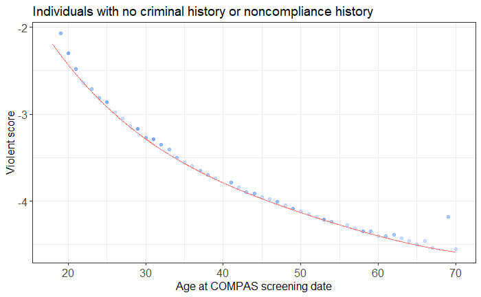

```r
inds_no_history = lb_inds %>%
    filter(vio_hist == 0 & history_noncomp == 0)
# nrow(inds_no_history) #97 inds
xmin = 18
xmax = 70
xx = seq(xmin,xmax, length.out=1000)
ggplot()+
  geom_point(aes(x=p_current_age, raw_score), color="#619CFF",alpha=.3, data=inds_no_history) +
  geom_line(aes(x=xx, predict(mdl_age, newdata=data.frame(p_current_age=xx))),color="#F8766D") +
  theme_bw()+
  ggtitle("Individuals with no criminal history or noncompliance history")+
  xlim(xmin,xmax)+
  xlab("Age at COMPAS screening date") +
  ylab("Violent score") +
  theme(text = element_text(size=12),
        axis.text=element_text(size=12),
        legend.position="none")
```

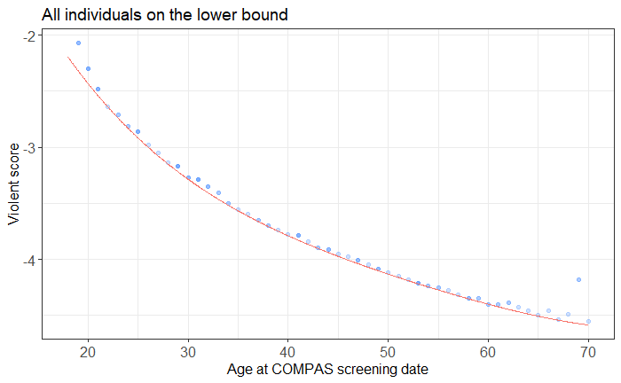

```r
ggplot()+
  geom_point(aes(x=p_current_age, raw_score), color="#619CFF",alpha=.3, data=lb_inds) +
  geom_line(aes(x=xx, predict(mdl_age, newdata=data.frame(p_current_age=xx))),color="#F8766D") +
  theme_bw()+
  ggtitle("All individuals on the lower bound")+
  xlim(xmin,xmax)+
  xlab("Age at COMPAS screening date") +
  ylab("Violent score") +
  theme(text = element_text(size=12),
        axis.text=element_text(size=12),
        legend.position="none")
```

Exploring relationship between COMPAS score and variables other than age - OLD CODE USING OLD VARNAMES

```r
ggplot(features, aes(x=p_age_first_offense, y=`Risk of Violence_raw_score`)) +
     geom_point(shape=1)  +
     ggtitle("Risk of Violence Raw vs Age at First Offense")

ggplot(poly_noage, aes(x=p_current_age, y=score_no_age)) +
     geom_point(shape=1)  +
     ggtitle("Risk of Violence Raw (No current age) vs Current Age")

ggplot(poly_noage, aes(x=p_age_first_offense, y=score_no_age)) +
     geom_point(shape=1)  +
     ggtitle("Risk of Violence Raw vs Age at First Offense, no current age")

#checking the relationship b/w DISTANCE b/w ages, and score
ggplot(poly_noage, aes(x=p_current_age-p_age_first_offense, y=`Risk of Violence_raw_score`)) +
     geom_point(shape=1)  +
     ggtitle("Risk of Violence Raw vs Current Age-Age at First Offense")

ggplot(poly_noage, aes(x=p_current_age-p_age_first_offense, y=score_no_age)) +
     geom_point(shape=1)  +
     ggtitle("Corrected Score vs Current Age-Age at First Offense")

#looking at people at bottom edge of corrected score vs p_age_first_offense
bottom_age1=train%>%
           group_by(p_age_first_offense)%>%
              arrange(`Risk of Violence_raw_score`-age_poly_viol(p_current_age),.by_group=TRUE)%>%
              top_n(n=-1,wt=`Risk of Violence_raw_score`)

ggplot(bottom_age1, aes(x=p_age_first_offense, y=`Risk of Violence_raw_score`-age_poly_viol(p_current_age))) +
     geom_point(shape=1)

#looking at people in age_subset (bottom edge of age vs raw violence score relationship) and plotting against age_first_offense instead
ggplot(lb_inds, aes(x=p_current_age, y=`Risk of Violence_raw_score`)) +
     geom_point(shape=1)  +
     ggtitle("Risk of Violence Raw vs Age at Current Offense, age_subset")

ggplot(lb_inds, aes(x=p_age_first_offense, y=`Risk of Violence_raw_score`)) +
     geom_point(shape=1)  +
     ggtitle("Risk of Violence Raw vs Age at First Offense, age_subset")
```

Trying to see the relationship between age at first offense and score, by looking at people who have only age contributing to their score (or as much so as possible)

```r
offense1=train%>%
          group_by(p_current_age)%>%
              arrange(`Risk of Violence_raw_score`,.by_group=TRUE)%>%
              top_n(n=-5,wt=`Risk of Violence_raw_score`)%>%
              ungroup()%>%
          filter(p_felony_count_person==0&(cq_fail_appear_two_yr+cq_fail_appear_two_plus)==0)


ggplot(offense1, aes(x=p_current_age, y=`Risk of Violence_raw_score`)) +
     geom_point(shape=1)  +
     geom_point(data=lb_inds, aes(x=p_current_age, y=`Risk of Violence_raw_score`),shape=1, color="red") +
     ggtitle("Risk of Violence Raw vs Age at Current Offense, offense1")

for(age in (18:60)){

  print(
    ggplot(filter(offense1, p_current_age==age) , aes(x=p_age_first_offense, y=`Risk of Violence_raw_score`)) +
     geom_point(shape=1)  +
     ggtitle(paste0("age=",age, ", offense1"))
  )

}

offense2=train%>%
          filter(p_felony_count_person==0&(cq_fail_appear_two_yr+cq_fail_appear_two_plus)==0
                 &p_current_age>40&p_age_first_offense<30)

ggplot(offense2, aes(x=p_current_age, y=`Risk of Violence_raw_score`)) +
     geom_point(shape=1)  +
     geom_point(data=lb_inds, aes(x=p_current_age, y=`Risk of Violence_raw_score`),shape=1, color="red") +
     ggtitle("Risk of Violence Raw vs Age at Current Offense, offense1")

ggplot(offense2, aes(x=p_age_first_offense, y=`Risk of Violence_raw_score`)) +
     geom_point(shape=1)  +
     ggtitle("Risk of Violence Raw vs Age at First Offense, offense1")

for(age in (18:60)){
  print(
    ggplot(filter(offense2, p_current_age==age) , aes(x=p_age_first_offense, y=`Risk of Violence_raw_score`)) +
     geom_point(shape=1)  +
     ggtitle(paste0("age=",age, ", offense1"))
  )

}
```

Same as above, but with p_age_first_arrest

```r
ggplot(train, aes(x=p_age_first_arrest, y=`Risk of Violence_raw_score`)) +
     geom_point(shape=1)  +
     ggtitle("Risk of Violence Raw vs Age at First Arrest")

ggplot(poly_noage, aes(x=p_current_age, y=score_no_age)) +
     geom_point(shape=1)  +
     ggtitle("Risk of Violence Raw (No current age) vs Current Age")

ggplot(poly_noage, aes(x=p_age_first_arrest, y=score_no_age)) +
     geom_point(shape=1)  +
     ggtitle("Risk of Violence Raw vs Age at First Arrest, no current age")

#checking the relationship b/w DISTANCE b/w ages, and score
ggplot(poly_noage, aes(x=p_current_age-p_age_first_arrest, y=`Risk of Violence_raw_score`)) +
     geom_point(shape=1)  +
     ggtitle("Risk of Violence Raw vs Current Age-Age at First Arrest")

ggplot(poly_noage, aes(x=p_current_age-p_age_first_arrest, y=score_no_age)) +
     geom_point(shape=1)  +
     ggtitle("Corrected Score vs Current Age-Age at First Arrest")

first_arrest_low=train%>%
                   mutate(score_no_age=`Risk of Violence_raw_score`-age_poly_viol(p_current_age))%>%
                   # filter(p_age_first_arrest<=20)%>%
                   filter(p_current_age!=p_age_first_arrest)%>%
                   filter(p_felprop_violarrest==0&p_misdemassault_arrest<=3&p_felassault_arrest==0
                          &p_murder_arrest==0&p_famviol_arrest==0&p_sex_arrest==0
                          &p_yrs5_felcount_person<=1&p_misdem_count_5yrs<=3&cq_fail_appear_two_yr<=3)

ggplot(first_arrest_low, aes(x=p_age_first_arrest, y=`Risk of Violence_raw_score`))+
  geom_point(shape=1)+
  ggtitle("Raw Score vs p_age_first_arrest, xlim<=20, no age=age@ first arrest")

ggplot(first_arrest_low, aes(x=p_age_first_arrest, y=score_no_age))+
  geom_point(shape=1)+
  ggtitle("Corrected Score vs p_age_first_arrest, xlim<=20, no age=age@ first arrest")
```

```r
ggplot(train, aes(x=p_yrs5_trafcount_person, y=`Risk of Violence_raw_score`-age_poly_viol(p_current_age)))+
  geom_point(shape=1)+
  ggtitle("Corrected Score vs 5 Yr Traffic")

#xlim to 3 b/c can only log on compas assessment as 0,1,2,3+
ggplot(train, aes(x=p_felassault_arrest, y=`Risk of Violence_raw_score`-age_poly_viol(p_current_age)))+
  geom_point(shape=1)+
  xlim(0,5)+ ylim(-1.5,3)+
  ggtitle("Corrected Score vs p_felassault_arrest")
```

```r
data_num=train%>%
                select(person_id,`Risk of Violence_raw_score`,p_recid_raw,p_fail_to_appear_raw,
                       p_current_age,cq_fail_appear_two_yr,cq_fail_appear_two_plus,
                       p_yrs5_felcount_person, p_felony_count_person,cq_prior_conviction_F,
                       p_misdem_count_5yrs,p_misdem_count_person,cq_prior_conviction_M,
                       p_drug_count_5yrs,p_drug_count_person,
                       p_yrs5_trafcount_person,p_traffic_count_person,prior_conviction_T,
                       p_current_violent_offense,
                       p_prison_visits,p_prison_time,
                       p_jail_visits, p_jail_time,
                       cq_violent_conviction,
                       p_marital_status,p_sex,p_race,
                       p_numcases
                       )%>%

                mutate(corrected_age=age_poly_viol(p_current_age))

write.csv(data_num,"data_num.csv")
```

Comparing generated COMPAS score vs original compas score With subtracted off age scores

```r
predicted_COMPAS=train%>%
                  mutate(total_fail_appear=cq_fail_appear_two_yr+cq_fail_appear_two_plus,
                         corrected_age=age_poly_viol(p_current_age)
)

#idea: limit the ranges of the variables in the history of violence scales to the multiple choice answers in the assessment
predicted_COMPAS_xlim=train%>%
                      mutate(total_fail_appear=cq_fail_appear_two_yr+cq_fail_appear_two_plus,
                             corrected_age=age_poly_viol(p_current_age),
                             p_felprop_violarrest=ifelse(p_felprop_violarrest>5,5,p_felprop_violarrest),
                             p_juv_fel_count=ifelse(p_juv_fel_count>2,2,p_juv_fel_count),
                             p_felassault_arrest=ifelse(p_felassault_arrest>3,3,p_felassault_arrest),
                             p_misdemassault_arrest=ifelse(p_misdemassault_arrest>3,3,
                                                           p_misdemassault_arrest),
                             p_murder_arrest=ifelse(p_murder_arrest>3,3,p_murder_arrest),
                             p_famviol_arrest=ifelse(p_famviol_arrest>3,3,p_famviol_arrest),
                             p_sex_arrest=ifelse(p_sex_arrest>3,3,p_sex_arrest),
                             p_weapons_arrest=ifelse(p_weapons_arrest>3,3,p_weapons_arrest),
                             total_fail_appear=ifelse(total_fail_appear>5,5,total_fail_appear)
                             )
```